# US Mass Shootings 1982 to 2019

## US Mass Shootings Over Time

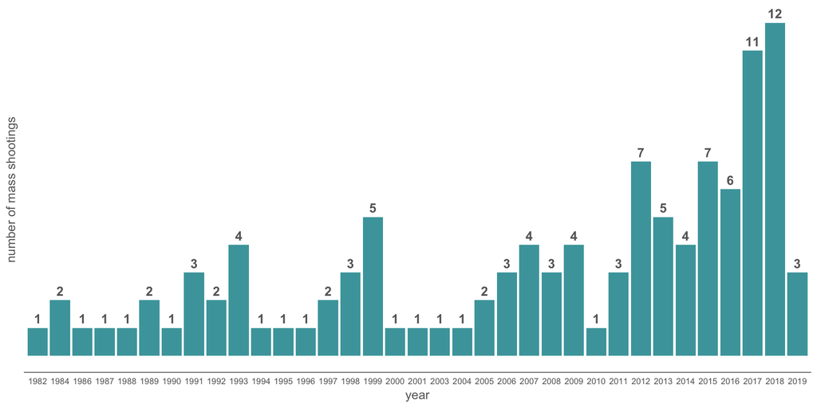

The number of mass shootings in the US is **increasing**.

The year with the most shootings was **2018** which consisted of **11%** of the mass shootings.

## US Mass Shootings By Gender

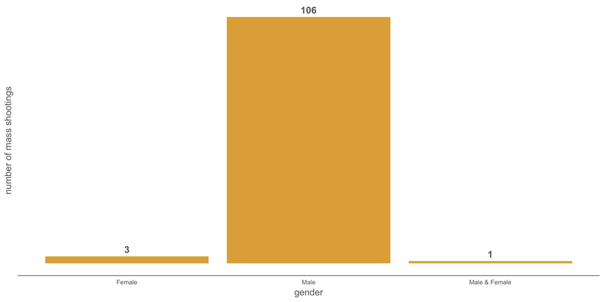

96% of mass shooters were **men**.

## US Mass Shootings By Race

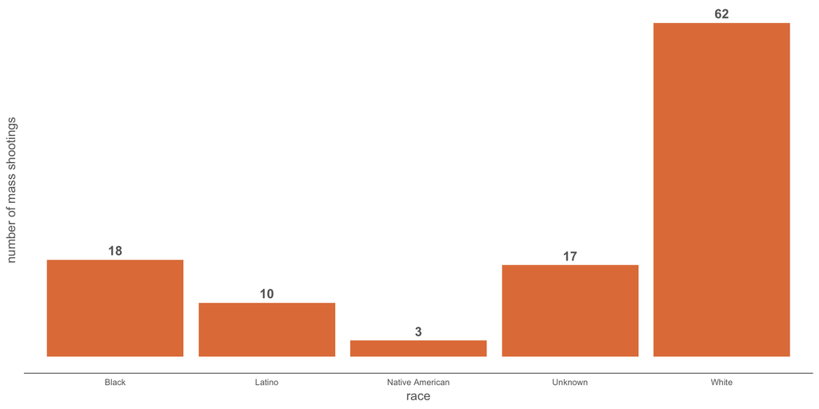

56% of mass shooters were **white**.

## Were There Prior Signs of Mental Health Issues?

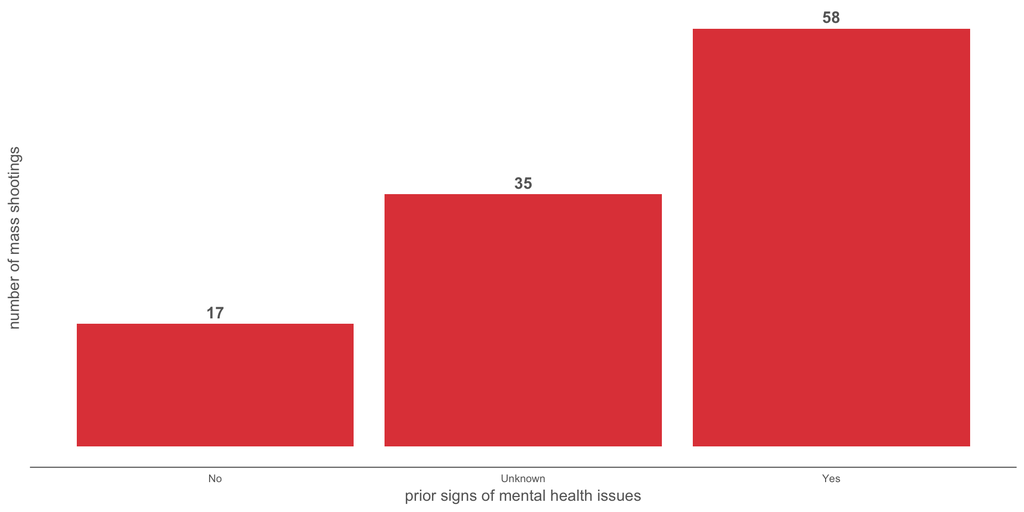

53% of mass shooters had **prior signs** of mental health issues.

## Were Weapons Obtained Legally?

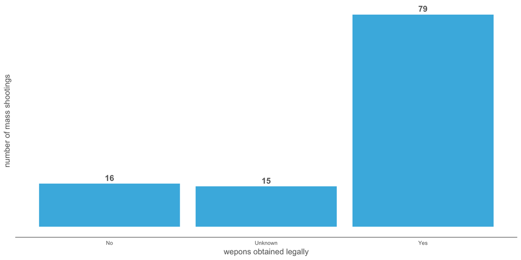

72% of mass shooters obtained weapons **legally**.

## US Mass Shootings By State

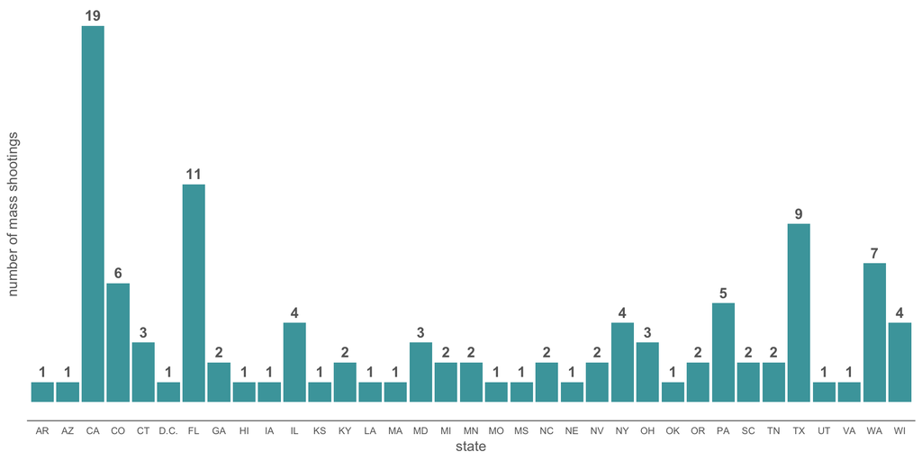

**California** is the state that has had the most mass shootings.

17% of the mass shootings were in California.

## US Mass Shootings By Location Type

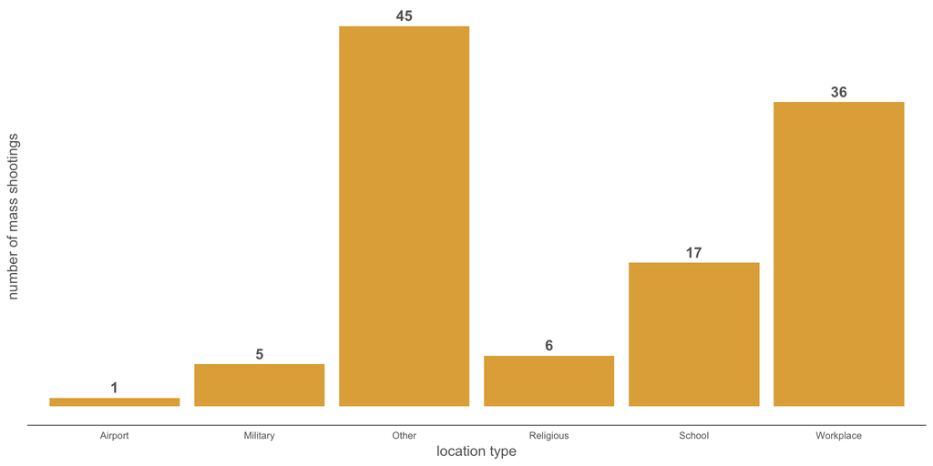

Putting locations classed as “Other” to one side, as we don’t know what types are included in that classification, the **workplace** is the most common location type for mass shootings (33%), with schools being the next most common (15%).

## Age Of Shooter

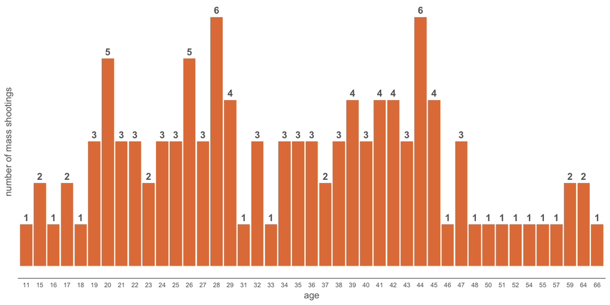

Shooter ages range from **11** to **66**.

## Age Bracket Of Shooter

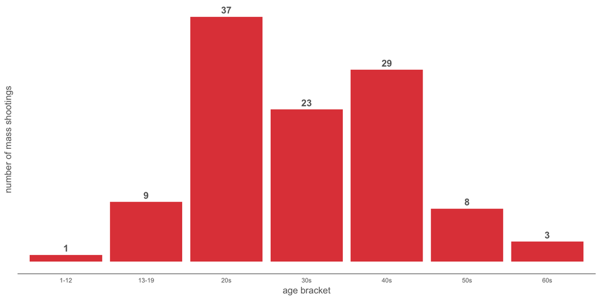

The age bracket with the highest number of mass shootings is the **20s** (34% of mass shootings).

## Semi-Automatic Weapons

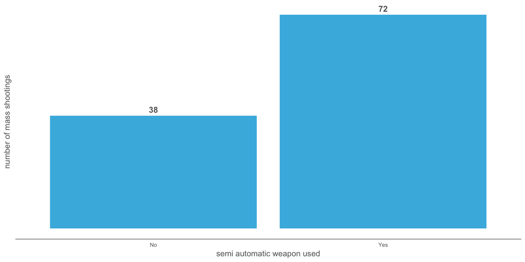

65% of mass shootings involved **semi-automatic weapons**.

## Multiple Weapons

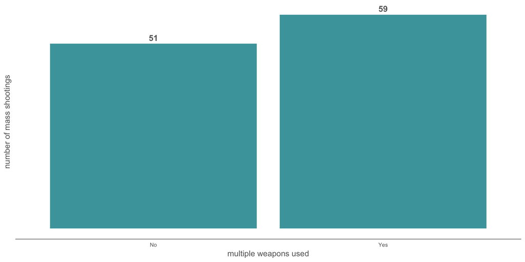

## State & Race

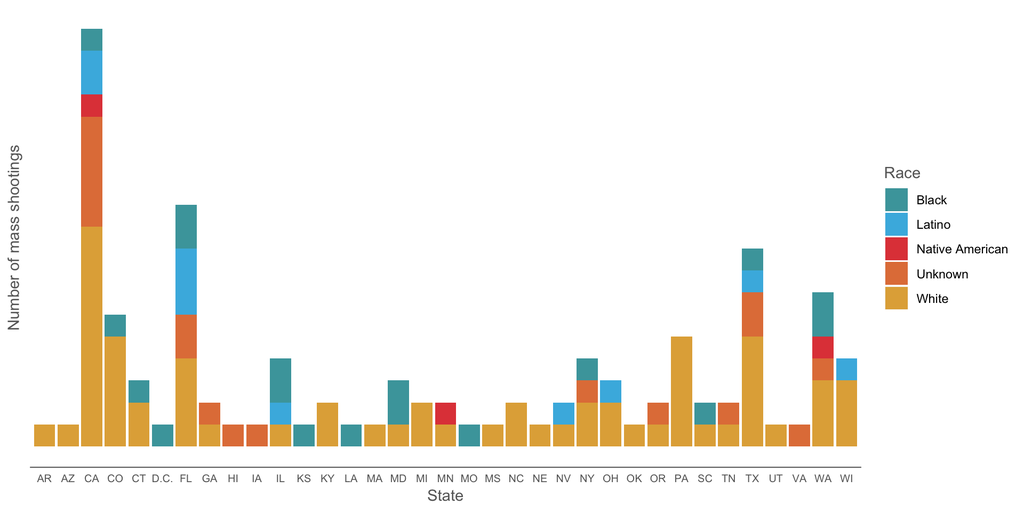

## State & Semi-Automatic Weapons

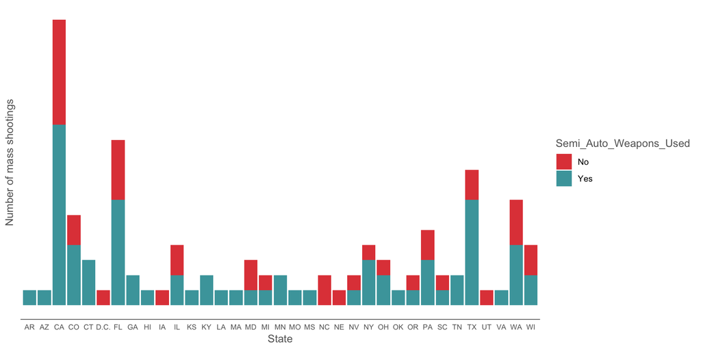

## State & Multiple Weapons

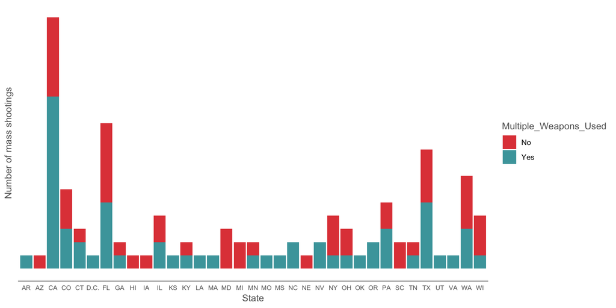

## State & Weapons Obtained Legally

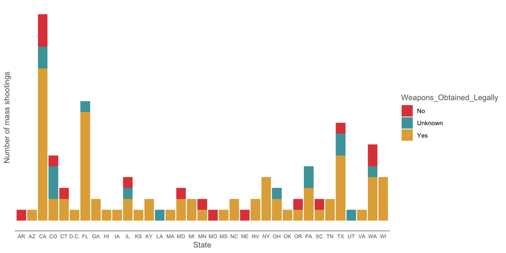

## State & Location Type

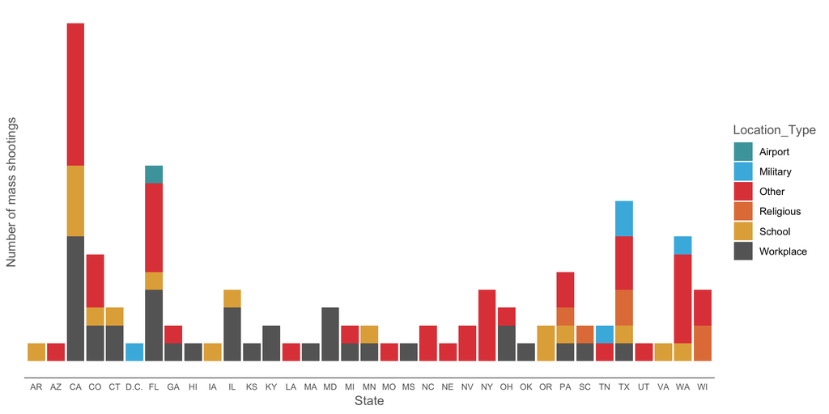

## State & Prior Signs of Mental Health Issues

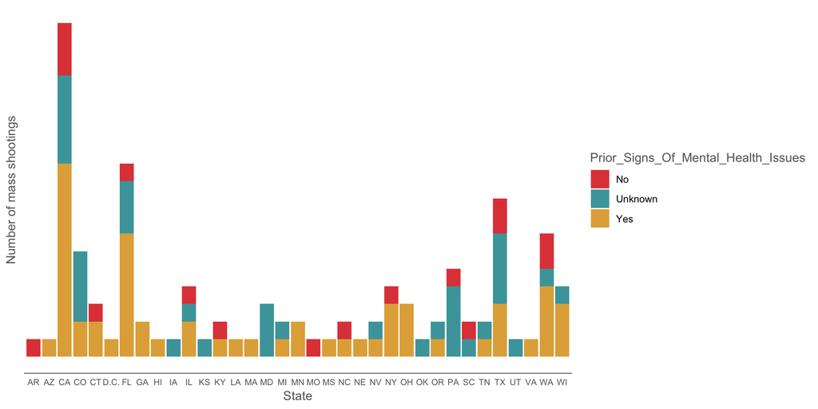

## State & Age Bracket

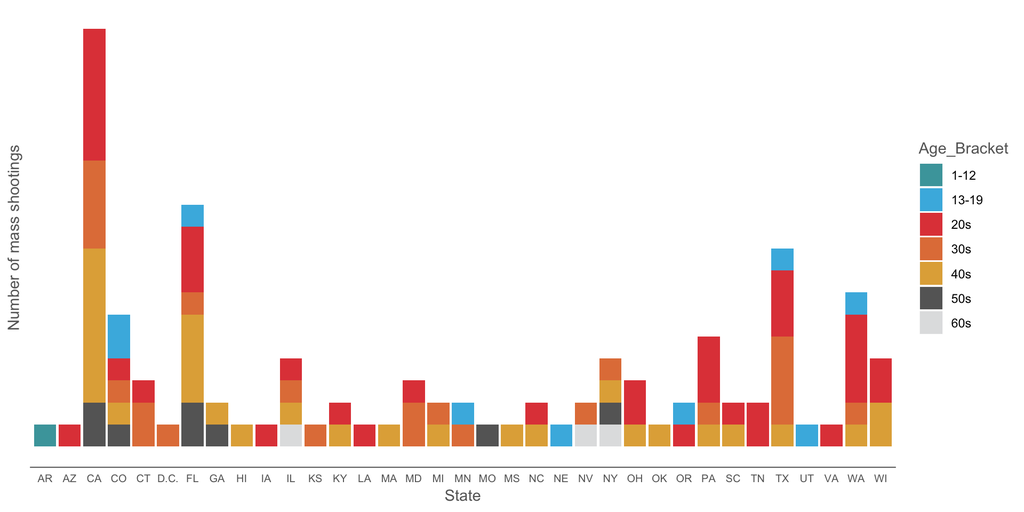

## Year & Semi-Automatic Weapons

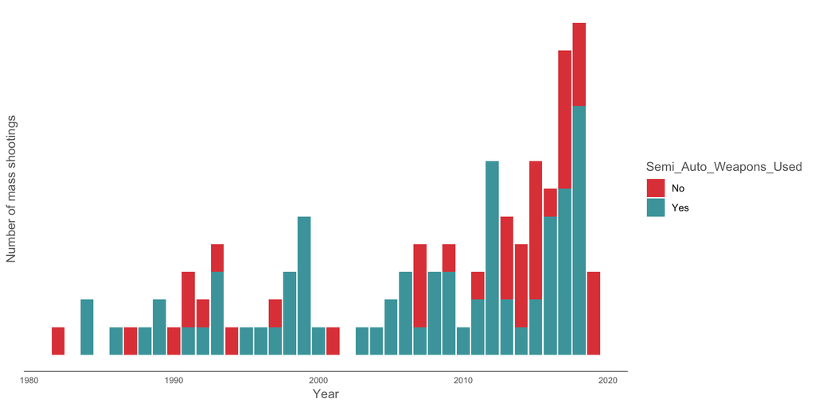

## Year & Multiple Weapons

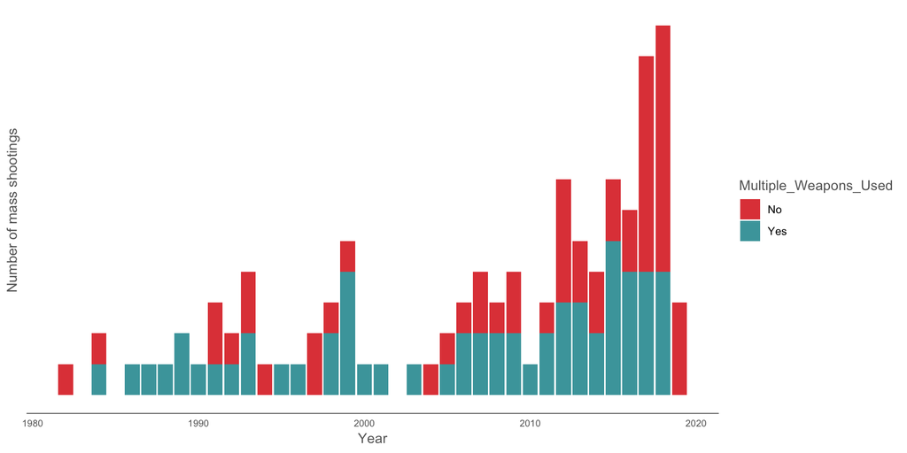

## Year & Age Bracket

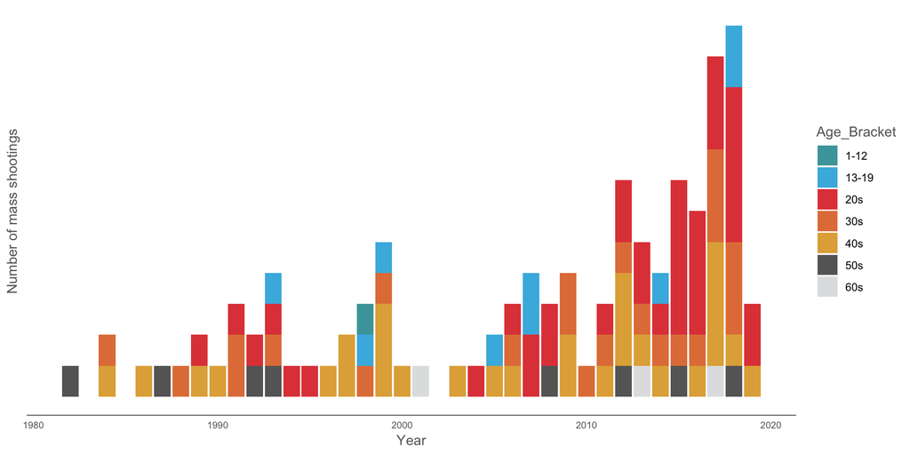

## Year & Prior Signs of Mental Health Issues

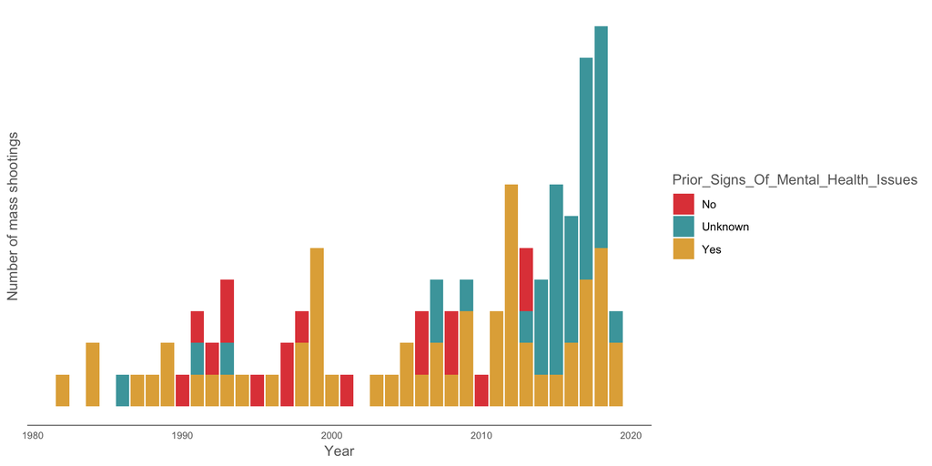

## Year & Weapons Obtained Legally

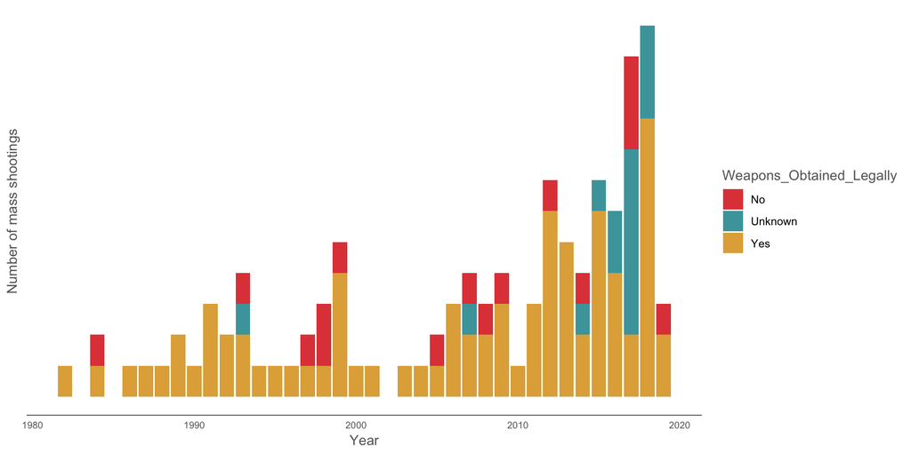

## Year & Location Type

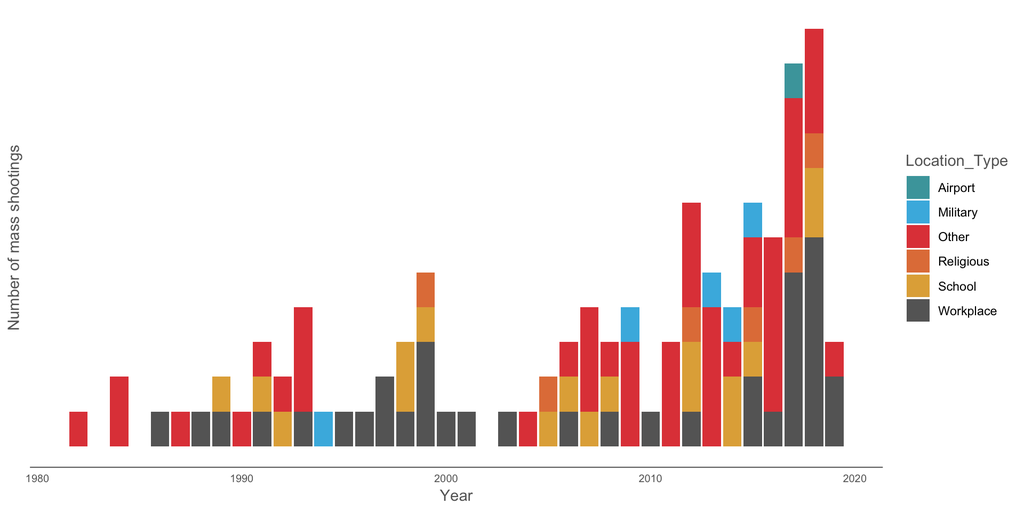

## Semi-Automatic Weapons & Prior Signs of Mental Health Issues

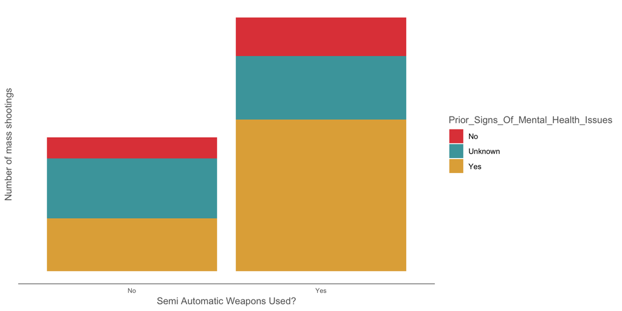

## Multiple Weapons & Prior Signs of Mental Health Issues

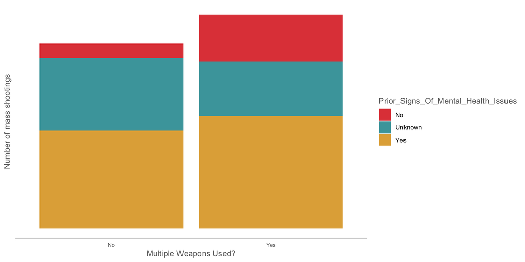

## Multiple Weapons & Semi-Automatic Weapons

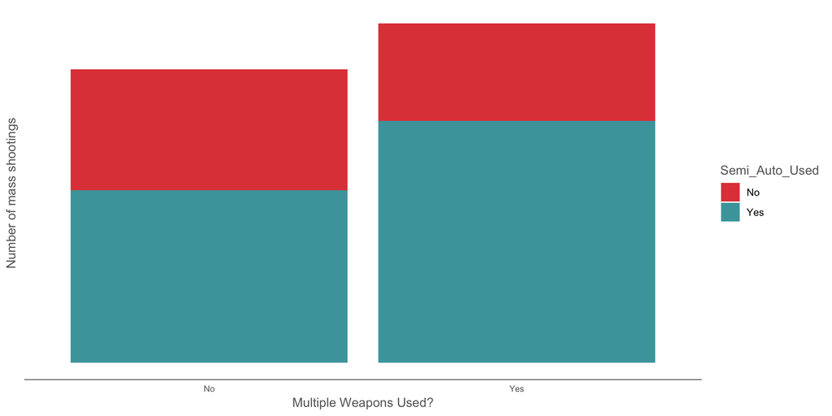

## Semi-Automatic Weapons & Age Bracket

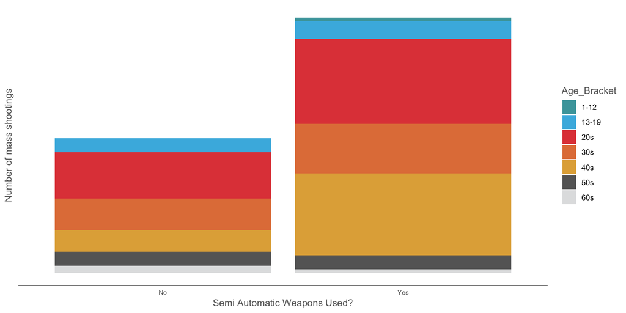

## Weapons Obtained Legally & Age Bracket

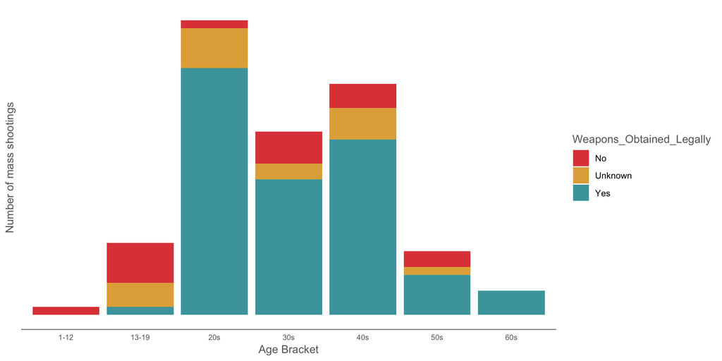

## Multiple Weapons & Age Bracket

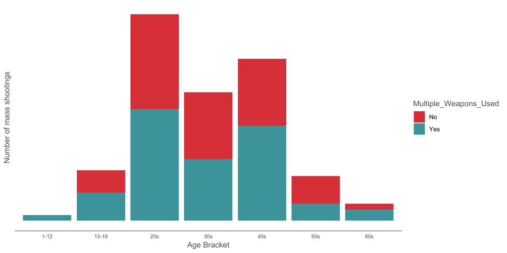